# Integrated ATAC-seq Data Analysis Workshop

Kai Hu, Haibo, Jianhong Ou, Lihua Julie Zhu

### Load required packages

```r
library(ATACseqQC)
library(TxDb.Hsapiens.UCSC.hg38.knownGene)
library(TxDb.Hsapiens.UCSC.hg19.knownGene)
library(BSgenome.Hsapiens.UCSC.hg38)
library(GenomicAlignments)
library(ChIPpeakAnno)
library(MotifDb)
library(jpeg)
```

### Demo I: assessing mapping status

```r
# Load datasets:
bam_good <- system.file("vignettes/extdata", "SRR891270.chr20.full.bam", package = "IntegratedATACseqAnalysisWorkshop2021")
bam_bad <- system.file("vignettes/extdata", "SRR5800802.chr20.full.bam", package = "IntegratedATACseqAnalysisWorkshop2021")

# Good dataset:
res_bamQC_good <- bamQC(bam_good, outPath=NULL)
head(res_bamQC_good)
```

```
## $totalQNAMEs
## [1] 311208
##
## $duplicateRate
## [1] 0
##
## $mitochondriaRate
## [1] 0
##
## $properPairRate
## [1] 0.9279864
##
## $unmappedRate
## [1] 0.007275048
##
## $hasUnmappedMateRate
## [1] 0.007275048
```

```r
# Bad dataset:
res_bamQC_bad <- bamQC(bam_bad, outPath=NULL)
head(res_bamQC_bad)
```

```
## $totalQNAMEs
## [1] 773454
##
## $duplicateRate
## [1] 0
##
## $mitochondriaRate
## [1] 0
##
## $properPairRate
## [1] 0.9750098
##
## $unmappedRate
## [1] 0.00260361
##
## $hasUnmappedMateRate
## [1] 0.00260361
```

Observation: the bam file quality of both files are good.

### Demo II: assessing sequencing depth and library complexity

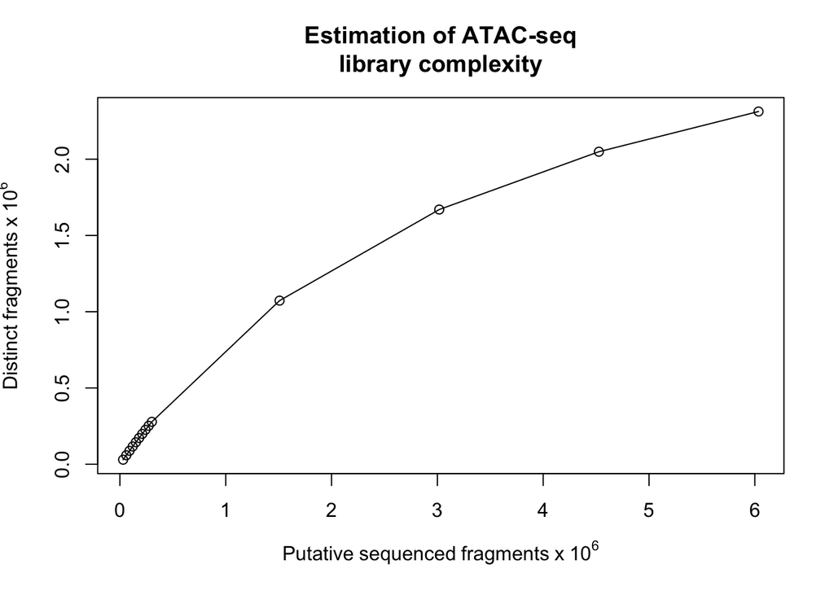

```r
estimateLibComplexity(readsDupFreq(bam_good))
```

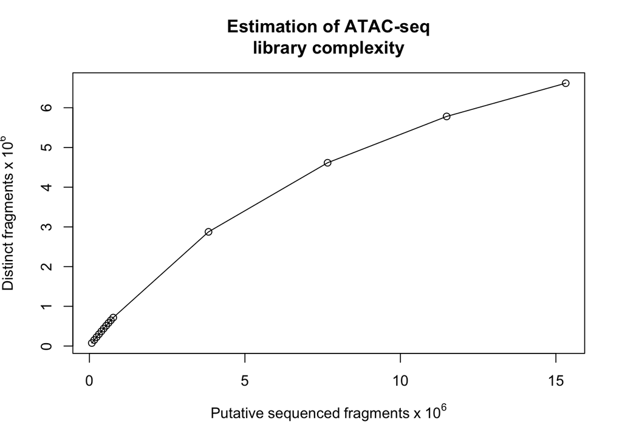

```r
estimateLibComplexity(readsDupFreq(bam_bad))
```

```r
#saturationPlot(macs2_peak_file, subsamplingSizes) # you need called peak files from MACS2 as input
```

Observation: the library complexity of both data sets are comparable. How to assess the sequencing depth? Try ?saturationPlot in RStudio.

### Demo III: assessing insert size distribution

```r
# Good dataset:
bam_good_label <- gsub(".full.bam", "", basename(bam_good))
fragSize <- fragSizeDist(bam_good, bam_good_label)
```

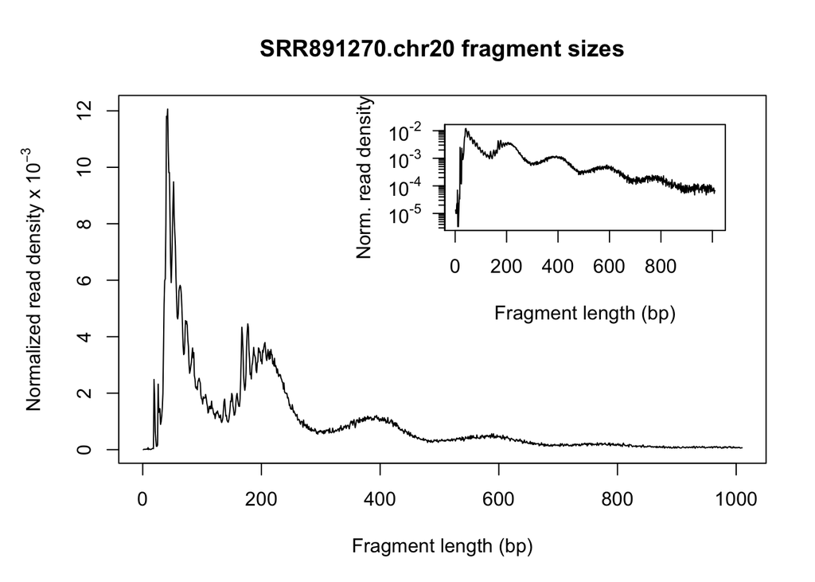

```r
# Bad dataset:
bam_bad_label <- gsub(".full.bam", "", basename(bam_bad))
fragSize <- fragSizeDist(bam_bad, bam_bad_label)
```

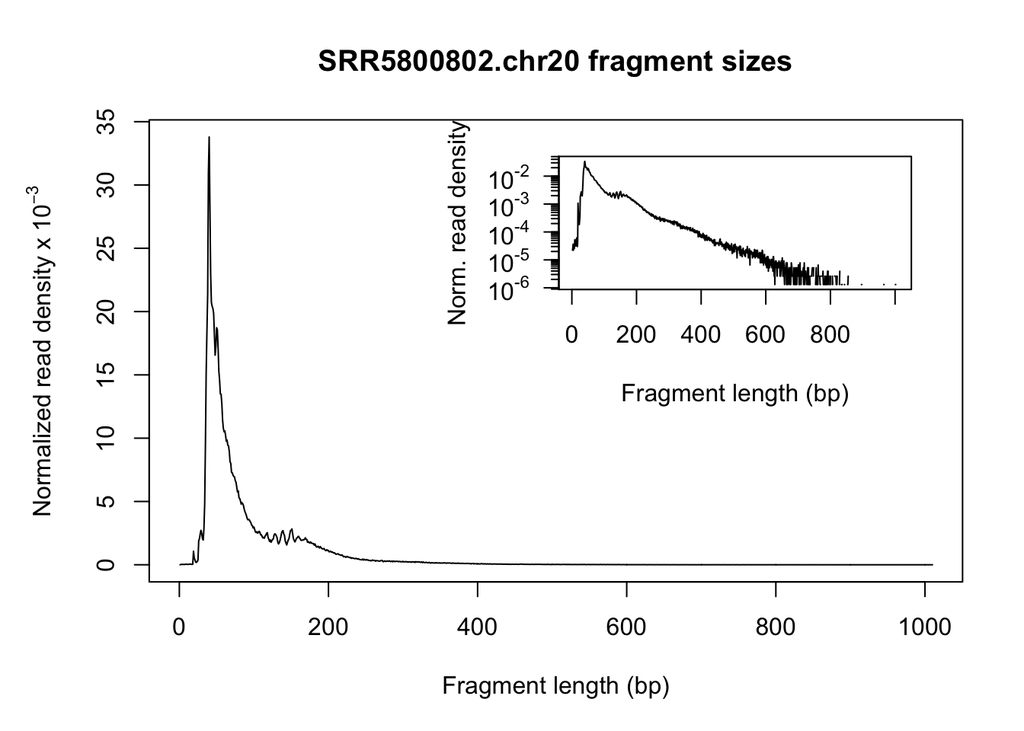

Observation: for the “good data”, we can observe the characteristic multi-peak pattern in the plot, whereas we can only detect one peak in the “bad data”, probably due to over-transposation.

### Demo IV: assessing similarities of replicates

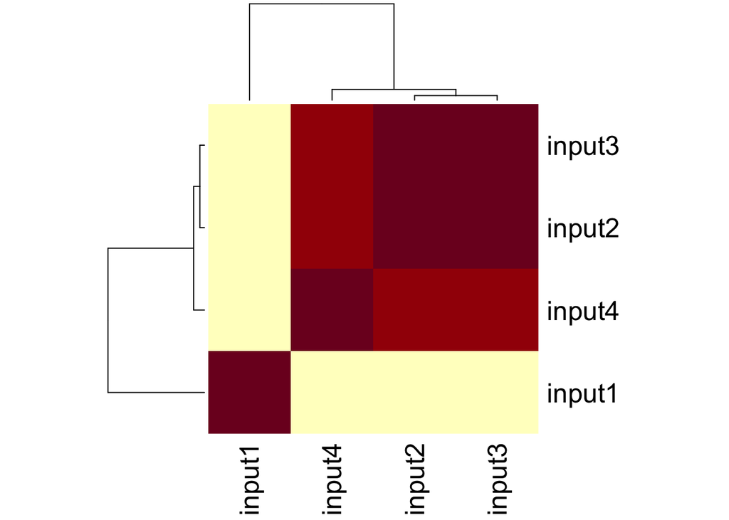

```r
bamfiles <- dir(system.file("extdata", package="ATACseqQC", mustWork=TRUE), "*.bam$", full.name=TRUE)
gals <- lapply(bamfiles, function(bamfile) {
    readBamFile(bamFile=bamfile, which=GRanges("chr1", IRanges(1, 1e6)), asMates=FALSE) })
plotCorrelation(GAlignmentsList(gals), transcripts(TxDb.Hsapiens.UCSC.hg19.knownGene), seqlev="chr1")
```

Observation: input1 is quite different from other samples.

### Demo V: shifting aligned reads

```r
# Good dataset:
gal_good <- readBamFile(bam_good, asMates = TRUE)
gal1_good <- shiftGAlignmentsList(gal_good, outbam = "shifted_good.bam")
head(gal1_good)
```

```
## GAlignments object with 6 alignments and 8 metadata columns:
##                      seqnames strand       cigar    qwidth     start       end
##                         <Rle>  <Rle> <character> <integer> <integer> <integer>
##   SRR891270.12311261    chr20      -         31M        31     60063     60093
##   SRR891270.12311261    chr20      +         31M        31     60068     60098
##   SRR891270.13563135    chr20      +         31M        31     60325     60355
##   SRR891270.13563135    chr20      -         37M        37     60309     60345
##    SRR891270.1077372    chr20      -         45M        45     60357     60401
##    SRR891270.1077372    chr20      +         46M        46     60086     60131
##                          width     njunc |              qname      flag
##                      <integer> <integer> |        <character> <integer>
##   SRR891270.12311261        31         0 | SRR891270.12311261        83
##   SRR891270.12311261        31         0 | SRR891270.12311261       163
##   SRR891270.13563135        31         0 | SRR891270.13563135        99
##   SRR891270.13563135        37         0 | SRR891270.13563135       147
##    SRR891270.1077372        45         0 |  SRR891270.1077372        83
##    SRR891270.1077372        46         0 |  SRR891270.1077372       163
##                           mapq     isize                     seq
##                      <integer> <numeric>          <DNAStringSet>
##   SRR891270.12311261         0       -26 GAGAGGGGTG...AGAGAGGTGG
##   SRR891270.12311261         0        26 GGGTGGAGGG...GGTGGGTAGG
##   SRR891270.13563135         0        21 ACTCCATTTC...CTCCATTCCA
##   SRR891270.13563135         0       -21 CACTCCATTC...TTCCACTGCA
##    SRR891270.1077372        60      -316 TTCACTCCAC...TCCACTCCAT
##    SRR891270.1077372        40       316 AGAGGTGGGT...TGCTGGATGT
##                                         qual     mrnm      mpos
##                               <PhredQuality> <factor> <integer>
##   SRR891270.12311261 BB@BD?1:)G...F?CB8FFDDD    chr20     60068
##   SRR891270.12311261 DFD<@FDFBE...FG8BCF-/-5    chr20     60063
##   SRR891270.13563135 HHDEGGHGGG...IICHGIIJ>C    chr20     60309
##   SRR891270.13563135 F@EBGB?:*F...CHC<:C<CC<    chr20     60325
##    SRR891270.1077372 CGD9GFHGBI...GIFCHFHFFE    chr20     60086
##    SRR891270.1077372 FFFFHDFHHG...FCEGIJFGHG    chr20     60357
##   -------
##   seqinfo: 194 sequences from an unspecified genome
```

```r
# Bad dataset:
gal_bad <- readBamFile(bam_bad, asMates = TRUE)
gal1_bad <- shiftGAlignmentsList(gal_bad, outbam = "shifted_bad.bam")
head(gal1_bad)
```

```
## GAlignments object with 6 alignments and 8 metadata columns:
##                       seqnames strand       cigar    qwidth     start       end
##                          <Rle>  <Rle> <character> <integer> <integer> <integer>
##   SRR5800802.35917639    chr20      +         46M        46     60091     60136
##   SRR5800802.35917639    chr20      -         45M        45     60102     60146
##   SRR5800802.43314545    chr20      -         39M        39     60218     60256
##   SRR5800802.43314545    chr20      +         40M        40     60222     60261
##   SRR5800802.11601916    chr20      -         30M        30     60222     60251
##   SRR5800802.11601916    chr20      +         32M        32     60226     60257
##                           width     njunc |               qname      flag
##                       <integer> <integer> |         <character> <integer>
##   SRR5800802.35917639        46         0 | SRR5800802.35917639        99
##   SRR5800802.35917639        45         0 | SRR5800802.35917639       147
##   SRR5800802.43314545        39         0 | SRR5800802.43314545        83
##   SRR5800802.43314545        40         0 | SRR5800802.43314545       163
##   SRR5800802.11601916        30         0 | SRR5800802.11601916        83
##   SRR5800802.11601916        32         0 | SRR5800802.11601916       163
##                            mapq     isize                     seq
##                       <integer> <numeric>          <DNAStringSet>
##   SRR5800802.35917639        40        56 TGGGTAGGAA...GATGTCATGC
##   SRR5800802.35917639        40       -56 ACTGGATTCC...TTAGCCCTCC
##   SRR5800802.43314545        60       -35 GCAATCCTTT...TCCACTCCAT
##   SRR5800802.43314545        60        35 TCCTTTCCTC...TCCATCCCAT
##   SRR5800802.11601916        22       -26 TCCTTTCCTT...TTCTCTCCAC
##   SRR5800802.11601916        22        26 TTCCTTTCCA...CCACTCCATC
##                                          qual     mrnm      mpos
##                                <PhredQuality> <factor> <integer>
##   SRR5800802.35917639 CGGGGGGGGG...GGGGGGGGGG    chr20     60102
##   SRR5800802.35917639 GGGGGGGGGG...GGGGGGGGGG    chr20     60091
##   SRR5800802.43314545 EGGDEGEDEG...EEFEGGDGDG    chr20     60222
##   SRR5800802.43314545 BGEGGGFFCG...GGGEFBGGG@    chr20     60218
##   SRR5800802.11601916 GGGGGGGGEG...GGGGGGGGFF    chr20     60226
##   SRR5800802.11601916 DGGGGGGGGG...GGGGGGGGGG    chr20     60222
##   -------
##   seqinfo: 194 sequences from an unspecified genome
```

### Demo VI: splitting bam file into bins

```r
txs <- transcripts(TxDb.Hsapiens.UCSC.hg38.knownGene)
    # good data:
obj_split_good <- splitGAlignmentsByCut(gal1_good, txs=txs, genome="Hsapiens", outPath = "split_bam_good")
    # bad data:
obj_split_bad <- splitGAlignmentsByCut(gal1_bad, txs=txs, genome="Hsapiens", outPath = "split_bam_bad")
dir("split_bam_good")
```

```
##  [1] "dinucleosome.bam"       "dinucleosome.bam.bai"   "inter1.bam"
##  [4] "inter1.bam.bai"         "inter2.bam"             "inter2.bam.bai"
##  [7] "inter3.bam"             "inter3.bam.bai"         "mononucleosome.bam"
## [10] "mononucleosome.bam.bai" "NucleosomeFree.bam"     "NucleosomeFree.bam.bai"
## [13] "others.bam"             "others.bam.bai"         "trinucleosome.bam"
## [16] "trinucleosome.bam.bai"
```

Observation: bam files are splited into multiple subset bam files.

### Demo VII: plotting aggregate signals around TSSs

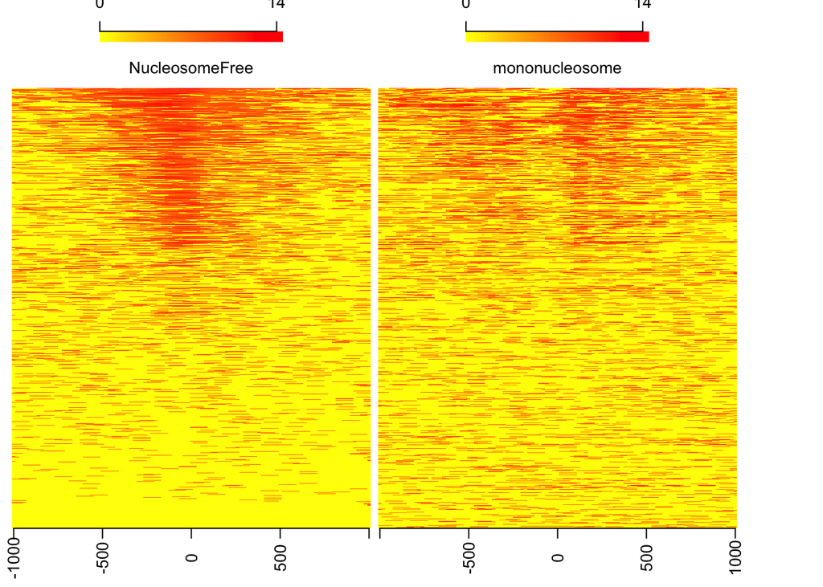

```r
# Good dataset:
bam_good_nuc <- file.path("split_bam_good", c("NucleosomeFree.bam", "mononucleosome.bam", "dinucleosome.bam", "trinucleosome.bam"))
    # find TSS coordinates:
TSS <- unique(promoters(txs, upstream=0, downstream=1))
    # estimate the library size for normalization:
librarySize <- estLibSize(bam_good_nuc)
    # calculate the signals around TSSs:
sigs <- enrichedFragments(gal = obj_split_good[c("NucleosomeFree", "mononucleosome", "dinucleosome", "trinucleosome")], TSS=TSS, librarySize=librarySize, TSS.filter=0.5, n.tile = 101, upstream = 1010, downstream = 1010)
    # log2 transform the signals:
sigs.log2 <- lapply(sigs, function(.ele) log2(.ele+1))
    # plot heatmap:
featureAlignedHeatmap(sigs.log2, reCenterPeaks(TSS, width=2020), zeroAt=.5, n.tile=101)
```

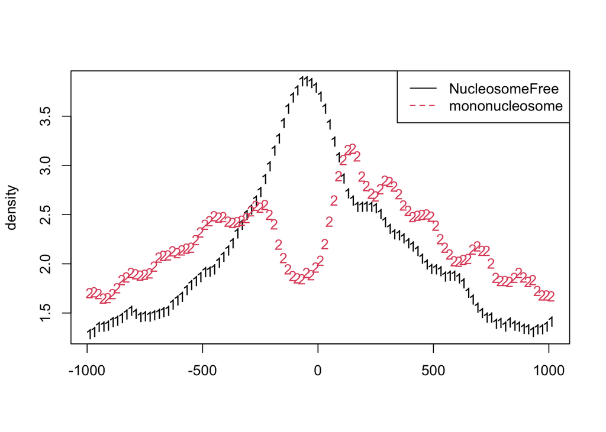

```r
    # density plot:
featureAlignedDistribution(sigs.log2, reCenterPeaks(TSS, width=2020), zeroAt=.5, n.tile=101)
```

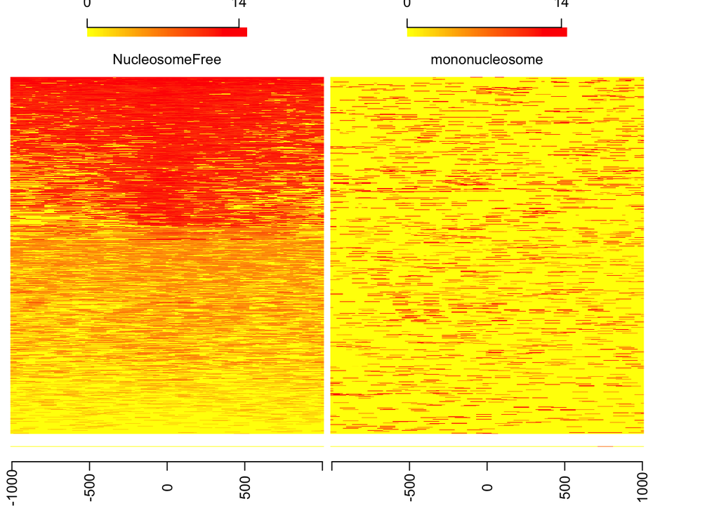

```r
# Bad dataset:
bam_bad_nuc <- file.path("split_bam_bad", c("NucleosomeFree.bam", "mononucleosome.bam", "dinucleosome.bam", "trinucleosome.bam"))
librarySize <- estLibSize(bam_bad_nuc)
sigs <- enrichedFragments(gal = obj_split_bad[c("NucleosomeFree", "mononucleosome", "dinucleosome", "trinucleosome")], TSS=TSS, librarySize=librarySize, TSS.filter=0.5, n.tile = 101, upstream = 1010, downstream = 1010)
sigs.log2 <- lapply(sigs, function(.ele) log2(.ele+1))
featureAlignedHeatmap(sigs.log2, reCenterPeaks(TSS, width=2020), zeroAt=.5, n.tile=101)
```

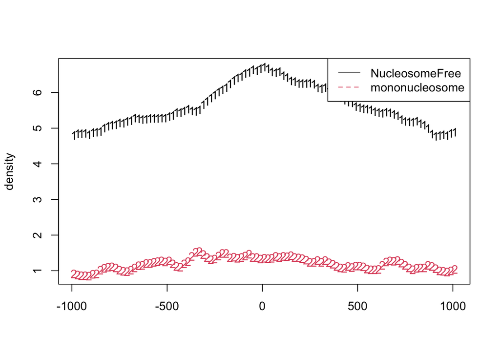

```r
featureAlignedDistribution(sigs.log2, reCenterPeaks(TSS, width=2020), zeroAt=.5, n.tile=101)
```

Observation: for good quality dataset, the nucleosome-free fragments are enriched around the center of the TSSs and the nucleosome-bound fragments are enriched flanking the center of the TSSs; for bad quality dataset, no such enrichments can be detected.

### Demo VIII: streamlining IGV snapshots

The goal of function `IGVSnapshot` is to facilitate the automatic visualization of signal distribution along any genomic region of interest. CAUTION: no white spaces are allowed in the full path to BAM files. NOTE: IGV must be available.

```r
# Load the IGVSnapshot.R from ATACseqQC:
source(system.file("extdata", "IGVSnapshot.R", package = "ATACseqQC"))

# IGVSnapshot(maxMem="lm", genomeBuild = "hg38",
#          bamFileFullPathOrURLs = bam_good_nuc,
#          geneNames = c("PQLC2", "MINOS1"))
```

Expected observation: for good quality dataset, reads are enriched to open chromatin regions whereas for bad quality dataset, reads are distributed across the entire genome.

### Demo IX: assessing DNA-binding factor footprints

Genomic regions bound by transcription factors/insulators are locally protected from Tn5 tagmentation and the pattern of Tn5 transposase cutting sites around TF-binding sites can be used to infer the footprints of TFs. The function `factorFootprints` is for plotting footprints of DNA-binding factors.

```r
# Get the CTCF motif info:
CTCF <- query(MotifDb, c("CTCF"))
CTCF <- as.list(CTCF)
head(CTCF[[1]], digits=2)
```

```
##       1     2     3     4     5     6     7     8     9    10    11    12    13
## A 0.100 0.162 0.302 0.072 0.012 0.786 0.024 0.122 0.914 0.012 0.376 0.022 0.028
## C 0.356 0.214 0.100 0.826 0.966 0.024 0.620 0.494 0.010 0.008 0.010 0.022 0.002
## G 0.122 0.406 0.436 0.050 0.012 0.108 0.336 0.056 0.048 0.976 0.602 0.606 0.962
## T 0.422 0.218 0.162 0.052 0.010 0.082 0.020 0.328 0.028 0.004 0.012 0.350 0.008
##      14    15    16    17    18    19
## A 0.024 0.096 0.424 0.086 0.122 0.342
## C 0.016 0.818 0.024 0.532 0.348 0.260
## G 0.880 0.038 0.522 0.326 0.122 0.318
## T 0.080 0.048 0.030 0.056 0.408 0.080
```

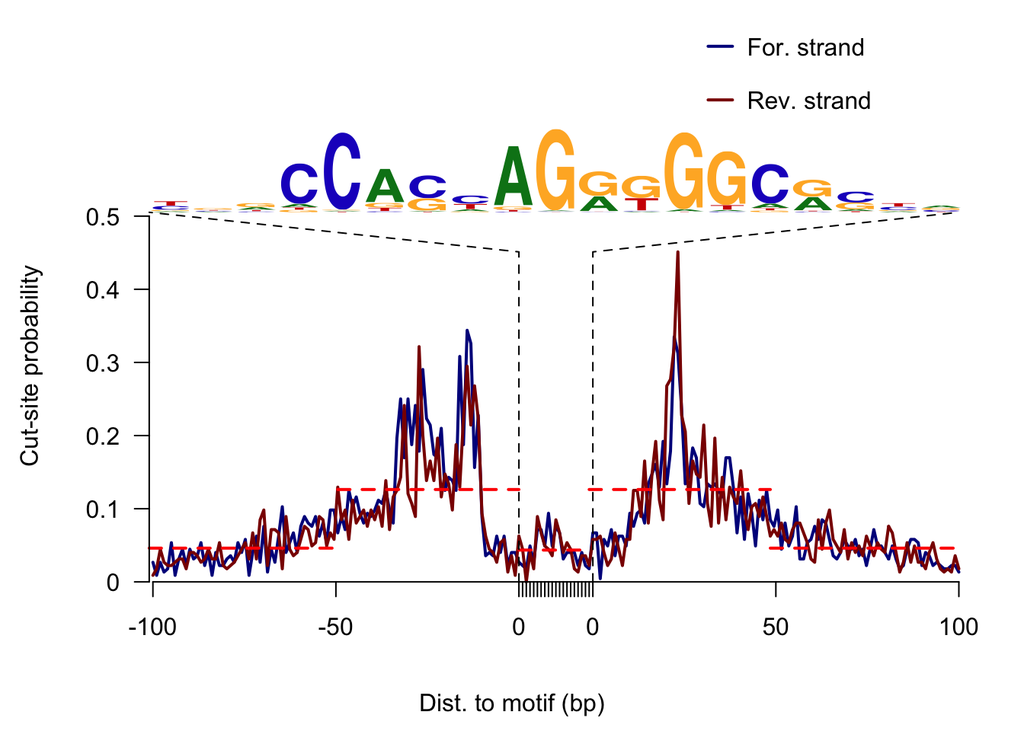

```r
# Good dataset:
factorFootprints("shifted_good.bam", pfm=CTCF[[1]], genome=Hsapiens, min.score="90%", upstream=100, downstream=100)
```

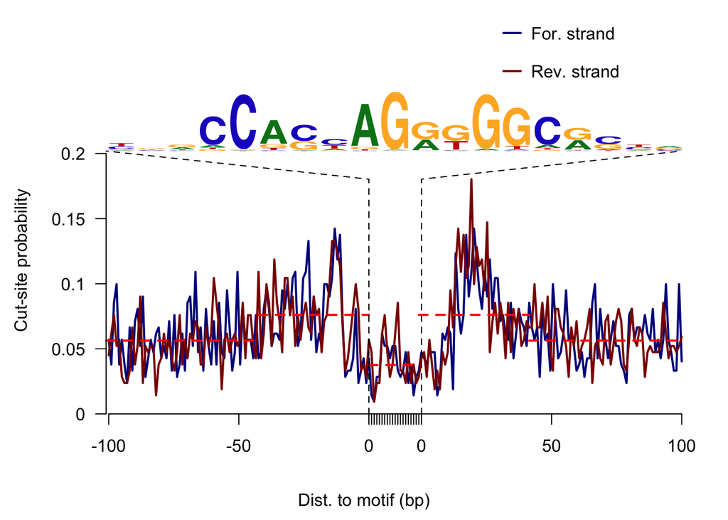

```r
# Bad dataset:
factorFootprints("shifted_bad.bam", pfm=CTCF[[1]], genome=Hsapiens, min.score="90%", upstream=100, downstream=100)
```

Observation: for good quality dataset, the “valley” is deep; for bad quality dataset, the “valley” is shallow. Note the y-scale.